# Analysis script

[Guillermo Montero-Melis](https://www.mpi.nl/people/montero-melis-guillermo)

# 1 Introduction

This document contains the analyses reported in the paper:

Melis et al., (submitted) “The impact of justified and unjustified inequality on perceived fairness and dishonesty”.

The document was generated with [knitr](https://yihui.org/knitr/). The R source code needed to generate this report is found in the following public OSF repository: https://osf.io/xt3hs/.

# 2 Set up workspace

Load libraries

Import data

Recode factor levels

Global variables (for figures and plots)

Convenience functions (loaded from script)

# 3 Experiment 1

Show first rows of the two data sets (see `README` for column key):

| subject | justification | pay | age | gender | anagram_score | donate_sweets | donate_number | like_sweets | lied | tempted_lie | fairness |
| --- | --- | --- | --- | --- | --- | --- | --- | --- | --- | --- | --- |
| 1 | unjustified | high | 18 | male | 7 | yes | 4 | yes | no | no | 7 |
| 2 | unjustified | low | 20 | male | 5 | no | 0 | yes | no | yes | 5 |
| 3 | justified | high | 19 | male | 4 | yes | 1 | yes | no | no | 6 |
| 4 | justified | low | 19 | male | 3 | yes | 2 | yes | yes | yes | 4 |
| 5 | unjustified | low | 18 | female | 6 | yes | 12 | no | no | no | 10 |
| 6 | unjustified | high | 18 | female | 2 | yes | 5 | yes | no | no | 10 |

| subject | roll | reported_score | RDR |
| --- | --- | --- | --- |
| 1 | 1 | 4 | 1 |
| 1 | 2 | 2 | 0 |
| 1 | 3 | 5 | 1 |
| 1 | 4 | 6 | 1 |
| 1 | 5 | 1 | 0 |
| 2 | 1 | 3 | 0 |

## 3.1 General descriptives

| gender | N |
| --- | --- |
| female | 95 |
| male | 65 |

Number of participants per condition:

| pay | justification | N |
| --- | --- | --- |
| high | justified | 40 |
| high | unjustified | 40 |
| low | justified | 40 |
| low | unjustified | 40 |

## 3.2 Coding scheme

Set coding scheme (contrast coding with difference of 1):

```
##      high_low
## high      0.5
## low      -0.5
```

```
##             just_unjust
## justified           0.5
## unjustified        -0.5
```

| subject | roll | reported_score | RDR | justification | pay |
| --- | --- | --- | --- | --- | --- |
| 1 | 1 | 4 | 1 | unjustified | high |
| 1 | 2 | 2 | 0 | unjustified | high |
| 1 | 3 | 5 | 1 | unjustified | high |
| 1 | 4 | 6 | 1 | unjustified | high |

## 3.3 Perceptions of fairness

Were fairness ratings affected by the manipulated variables: payment and justification?

### 3.3.1 Descriptives

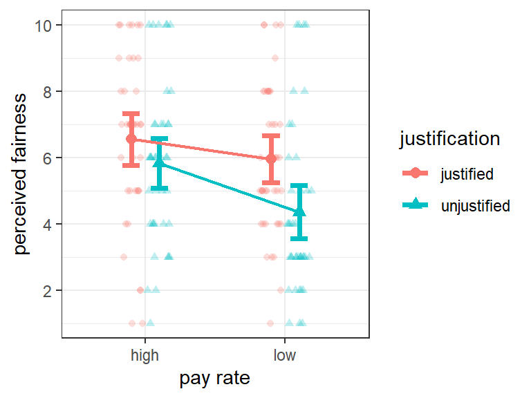

| pay | mean | SD |
| --- | --- | --- |
| high | 6.19 | 2.49 |
| low | 5.15 | 2.56 |

| justification | mean | SD |
| --- | --- | --- |
| justified | 6.25 | 2.42 |
| unjustified | 5.09 | 2.60 |

| pay | justification | mean | SD |
| --- | --- | --- | --- |
| high | justified | 6.55 | 2.52 |
| high | unjustified | 5.83 | 2.43 |
| low | justified | 5.95 | 2.30 |
| low | unjustified | 4.35 | 2.59 |

### 3.3.2 Linear regression

```
##
## Call:
## lm(formula = fairness ~ pay * justification, data = e1_ppt)
##
## Residuals:
##    Min     1Q Median     3Q    Max
##  -5.55  -1.55   0.05   1.50   5.65
##
## Coefficients:
##                                      Estimate Std. Error t value Pr(>|t|)
## (Intercept)                            5.6688     0.1945  29.139  < 2e-16
## payhigh_low                            1.0375     0.3891   2.666  0.00847
## justificationjust_unjust               1.1625     0.3891   2.988  0.00327
## payhigh_low:justificationjust_unjust  -0.8750     0.7782  -1.124  0.26256
##
## (Intercept)                          ***
## payhigh_low                          **
## justificationjust_unjust             **
## payhigh_low:justificationjust_unjust
## ---
## Signif. codes:  0 '***' 0.001 '**' 0.01 '*' 0.05 '.' 0.1 ' ' 1
##
## Residual standard error: 2.461 on 156 degrees of freedom
## Multiple R-squared:  0.09983,    Adjusted R-squared:  0.08252
## F-statistic: 5.767 on 3 and 156 DF,  p-value: 0.0009128
```

|  | fairness |  |  |  |
| --- | --- | --- | --- | --- |
| Predictors | Estimates | CI | Statistic | p |
| (Intercept) | 5.67 | 5.29 – 6.05 | 29.14 | **<0.001** |
| payhigh_low | 1.04 | 0.27 – 1.80 | 2.67 | **0.008** |
| justificationjust_unjust | 1.16 | 0.40 – 1.93 | 2.99 | **0.003** |
| payhigh_low:justificationjust_unjust | -0.88 | -2.40 – 0.65 | -1.12 | 0.263 |
| Observations | 160 |  |  |  |
| R<sup>2</sup> / R<sup>2</sup> adjusted | 0.100 / 0.083 |  |  |  |

**Same model with standardized coefficients:**

|  | fairness_z |  |  |  |
| --- | --- | --- | --- | --- |
| Predictors | Estimates | CI | Statistic | p |
| (Intercept) | -0.00 | -0.15 – 0.15 | -0.00 | 1.000 |
| pay_z | 0.20 | 0.05 – 0.35 | 2.67 | **0.008** |
| justification_z | 0.23 | 0.08 – 0.38 | 2.99 | **0.003** |
| pay_z:justification_z | -0.09 | -0.24 – 0.06 | -1.12 | 0.263 |
| Observations | 160 |  |  |  |
| R<sup>2</sup> / R<sup>2</sup> adjusted | 0.100 / 0.083 |  |  |  |

## 3.4 Reported rewarded dice rolls (RDRs)

### 3.4.1 Descriptives

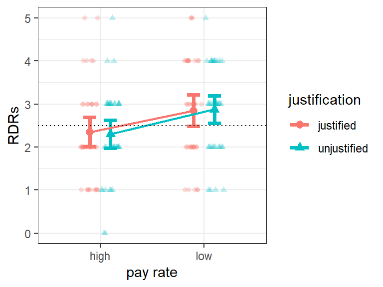

| pay | mean | SD |
| --- | --- | --- |
| high | 2.33 | 1.06 |
| low | 2.86 | 1.09 |

| justification | mean | SD |
| --- | --- | --- |
| justified | 2.60 | 1.15 |
| unjustified | 2.59 | 1.06 |

| pay | justification | mean | SD |
| --- | --- | --- | --- |
| high | justified | 2.35 | 1.10 |
| high | unjustified | 2.30 | 1.04 |
| low | justified | 2.85 | 1.17 |
| low | unjustified | 2.88 | 1.02 |

### 3.4.2 Binomial regression

```
##
## Call:
## glm(formula = cbind(RDRs, 5 - RDRs) ~ pay * justification, family = "binomial",
##     data = e1_RDR)
##
## Deviance Residuals:
##     Min       1Q   Median       3Q      Max
## -2.4823  -0.7630   0.1134   0.6275   2.7866
##
## Coefficients:
##                                       Estimate Std. Error z value Pr(>|z|)
## (Intercept)                           0.075911   0.071178   1.066  0.28620
## payhigh_low                          -0.432309   0.142356  -3.037  0.00239
## justificationjust_unjust              0.009884   0.142356   0.069  0.94464
## payhigh_low:justificationjust_unjust  0.060628   0.284713   0.213  0.83137
##
## (Intercept)
## payhigh_low                          **
## justificationjust_unjust
## payhigh_low:justificationjust_unjust
## ---
## Signif. codes:  0 '***' 0.001 '**' 0.01 '*' 0.05 '.' 0.1 ' ' 1
##
## (Dispersion parameter for binomial family taken to be 1)
##
##     Null deviance: 179.69  on 159  degrees of freedom
## Residual deviance: 170.37  on 156  degrees of freedom
## AIC: 481.9
##
## Number of Fisher Scoring iterations: 4
```

|  | cbind(RDRs, 5 - RDRs) |  |  |  |
| --- | --- | --- | --- | --- |
| Predictors | Odds Ratios | CI | Statistic | p |
| (Intercept) | 1.08 | 0.94 – 1.24 | 1.07 | 0.286 |
| payhigh_low | 0.65 | 0.49 – 0.86 | -3.04 | **0.002** |
| justificationjust_unjust | 1.01 | 0.76 – 1.33 | 0.07 | 0.945 |
| payhigh_low:justificationjust_unjust | 1.06 | 0.61 – 1.86 | 0.21 | 0.831 |
| Observations | 160 |  |  |  |
| R<sup>2</sup> Tjur | 0.008 |  |  |  |

### 3.4.3 Comparison against chance

Comparison against chance of the number of RDRs in the two payment conditions (high vs. low) :

```
##
## Call:
## glm(formula = cbind(RDRs, 5 - RDRs) ~ 1, family = "binomial",
##     data = .)
##
## Deviance Residuals:
##     Min       1Q   Median       3Q      Max
## -1.7058  -0.7744   0.1247   1.0759   2.3617
##
## Coefficients:
##             Estimate Std. Error z value Pr(>|z|)
## (Intercept)   0.2921     0.1011    2.89  0.00386 **
## ---
## Signif. codes:  0 '***' 0.001 '**' 0.01 '*' 0.05 '.' 0.1 ' ' 1
##
## (Dispersion parameter for binomial family taken to be 1)
##
##     Null deviance: 86.372  on 79  degrees of freedom
## Residual deviance: 86.372  on 79  degrees of freedom
## AIC: 239.67
##
## Number of Fisher Scoring iterations: 4
```

|  | cbind(RDRs, 5 - RDRs) |  |  |  |
| --- | --- | --- | --- | --- |
| Predictors | Odds Ratios | CI | Statistic | p |
| (Intercept) | 1.34 | 1.10 – 1.63 | 2.89 | **0.004** |
| Observations | 80 |  |  |  |
| R<sup>2</sup> Tjur | 0.000 |  |  |  |

```
##
## Call:
## glm(formula = cbind(RDRs, 5 - RDRs) ~ 1, family = "binomial",
##     data = .)
##
## Deviance Residuals:
##     Min       1Q   Median       3Q      Max
## -2.5010  -0.2927  -0.2927   0.6051   2.7672
##
## Coefficients:
##             Estimate Std. Error z value Pr(>|z|)
## (Intercept)  -0.1402     0.1002  -1.399    0.162
##
## (Dispersion parameter for binomial family taken to be 1)
##
##     Null deviance: 84.045  on 79  degrees of freedom
## Residual deviance: 84.045  on 79  degrees of freedom
## AIC: 238.28
##
## Number of Fisher Scoring iterations: 3
```

|  | cbind(RDRs, 5 - RDRs) |  |  |  |
| --- | --- | --- | --- | --- |
| Predictors | Odds Ratios | CI | Statistic | p |
| (Intercept) | 0.87 | 0.71 – 1.06 | -1.40 | 0.162 |
| Observations | 80 |  |  |  |
| R<sup>2</sup> Tjur | 0.000 |  |  |  |

### 3.4.4 Mediation analysis

**Rationale**

Only payment type affected reported RDRs, but both manipulations affected perceived fairness. This motivates a mediation analysis to better understand the causality chain in our model (Baron and Kenny, 1986). It could be the case that our manipulations did not affect participants’ cheating behaviour directly, but rather through the mediation of a third variable, perceived fairness. To evaluate this possibility we proceeded in three steps (cf. Baron and Kenny, 1986):

1. We established that the potential mediator variable (perceived fairness) is predicted by the experimental manipulations (justification and payment). This was our first analysis, which indeed revealed a significant effect of both variables on perceived fairness.
2. We established that the critical outcome (RDR) is significantly predicted by the experimental manipulations. This was our second analysis, which indicated that payment indeed was a reliable predictor of RDR.
3. As the final step, we now regress RDR against the experimental manipulations *and* perceived fairness, so that the effect of the manipulations is estimated while controlling for the effects of the potential mediator and viceversa.

**Logic**

If the effect of our manipulations on reported RDRs is completely mediated by perceived fairness, then payment type should not be a significant predictor of RDR in this new model anymore.

| subject | pay | justification | RDRs | fairness | fairness_c |
| --- | --- | --- | --- | --- | --- |
| 1 | high | unjustified | 3 | 7 | 1.33125 |
| 2 | low | unjustified | 3 | 5 | -0.66875 |
| 3 | high | justified | 2 | 6 | 0.33125 |
| 4 | low | justified | 3 | 4 | -1.66875 |

**Model summary**

```
##
## Call:
## glm(formula = cbind(RDRs, 5 - RDRs) ~ pay * justification + fairness_c,
##     family = "binomial", data = e1_RDR)
##
## Deviance Residuals:
##      Min        1Q    Median        3Q       Max
## -2.47842  -0.73780   0.03093   0.67238   2.82567
##
## Coefficients:
##                                      Estimate Std. Error z value Pr(>|z|)
## (Intercept)                           0.07597    0.07121   1.067  0.28604
## payhigh_low                          -0.40849    0.14545  -2.808  0.00498
## justificationjust_unjust              0.03694    0.14642   0.252  0.80085
## fairness_c                           -0.02328    0.02928  -0.795  0.42662
## payhigh_low:justificationjust_unjust  0.04035    0.28596   0.141  0.88779
##
## (Intercept)
## payhigh_low                          **
## justificationjust_unjust
## fairness_c
## payhigh_low:justificationjust_unjust
## ---
## Signif. codes:  0 '***' 0.001 '**' 0.01 '*' 0.05 '.' 0.1 ' ' 1
##
## (Dispersion parameter for binomial family taken to be 1)
##
##     Null deviance: 179.69  on 159  degrees of freedom
## Residual deviance: 169.73  on 155  degrees of freedom
## AIC: 483.27
##
## Number of Fisher Scoring iterations: 4
```

|  | cbind(RDRs, 5 - RDRs) |  |  |  |
| --- | --- | --- | --- | --- |
| Predictors | Odds Ratios | CI | Statistic | p |
| (Intercept) | 1.08 | 0.94 – 1.24 | 1.07 | 0.286 |
| payhigh_low | 0.66 | 0.50 – 0.88 | -2.81 | **0.005** |
| justificationjust_unjust | 1.04 | 0.78 – 1.38 | 0.25 | 0.801 |
| fairness_c | 0.98 | 0.92 – 1.03 | -0.79 | 0.427 |
| payhigh_low:justificationjust_unjust | 1.04 | 0.59 – 1.82 | 0.14 | 0.888 |
| Observations | 160 |  |  |  |
| R<sup>2</sup> Tjur | 0.007 |  |  |  |

**Conclusion**

Payment remains the only significant predictor of RDR. Its estimated coefficient is virtually unchanged with regard to its size and its significance, compared to the model that did not included perceived fairness as a predictor. At the same time, perceived fairness does not have a significant effect on RDR. Hence, we find no evidence that the effect of the manipulations on cheating behaviour (RDRs) is mediated by perceived fairness.

**Additional (more complex) model**

In a footnote we allude to an additional regression model in which RDR was regressed against justification, payment, perceived fairness *and all possible interactions between them* (see Baron & Kenny, 1986 for a motivation of such a model in situations where there is both mediation and moderation). The model summary is shown below. The results are qualitatively identical to the ones of the simpler model.

|  | cbind(RDRs, 5 - RDRs) |  |  |  |
| --- | --- | --- | --- | --- |
| Predictors | Odds Ratios | CI | Statistic | p |
| (Intercept) | 1.07 | 0.92 – 1.24 | 0.87 | 0.385 |
| payhigh_low | 0.69 | 0.51 – 0.92 | -2.52 | **0.012** |
| justificationjust_unjust | 1.06 | 0.79 – 1.42 | 0.41 | 0.683 |
| fairness_c | 0.98 | 0.92 – 1.04 | -0.71 | 0.479 |
| payhigh_low:justificationjust_unjust | 1.02 | 0.57 – 1.84 | 0.08 | 0.937 |
| payhigh_low:fairness_c | 1.00 | 0.89 – 1.12 | 0.01 | 0.992 |
| justificationjust_unjust:fairness_c | 1.02 | 0.91 – 1.14 | 0.31 | 0.754 |
| payhigh_low:justificationjust_unjust:fairness_c | 0.90 | 0.71 – 1.13 | -0.90 | 0.366 |
| Observations | 160 |  |  |  |
| R<sup>2</sup> Tjur | 0.007 |  |  |  |

**Visual check**

Visually, there is indeed no indication of an effect of any variable apart from payment:

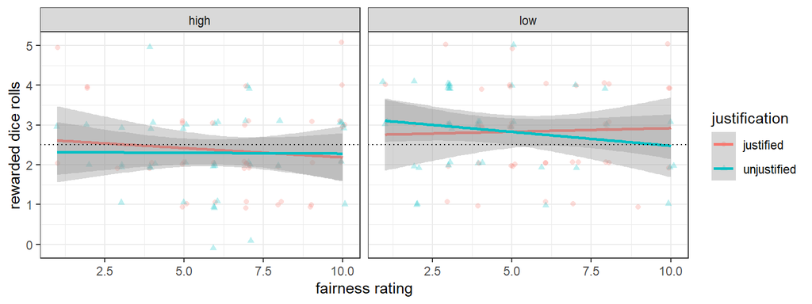

## 3.5 Reported cheating and temptation to cheat

Overall, 10% of the participants reported cheating and 40.6% reported being tempted to lie.

**Descriptive table**

| pay | justification | N | reported cheating | cheat % | tempted to cheat | tempted % |
| --- | --- | --- | --- | --- | --- | --- |
| high | justified | 40 | 2 | 5.0 | 10 | 25.0 |
| high | unjustified | 40 | 4 | 10.0 | 9 | 22.5 |
| low | justified | 40 | 5 | 12.5 | 22 | 55.0 |
| low | unjustified | 40 | 5 | 12.5 | 24 | 60.0 |

### 3.5.1 Reported cheating

Visually:

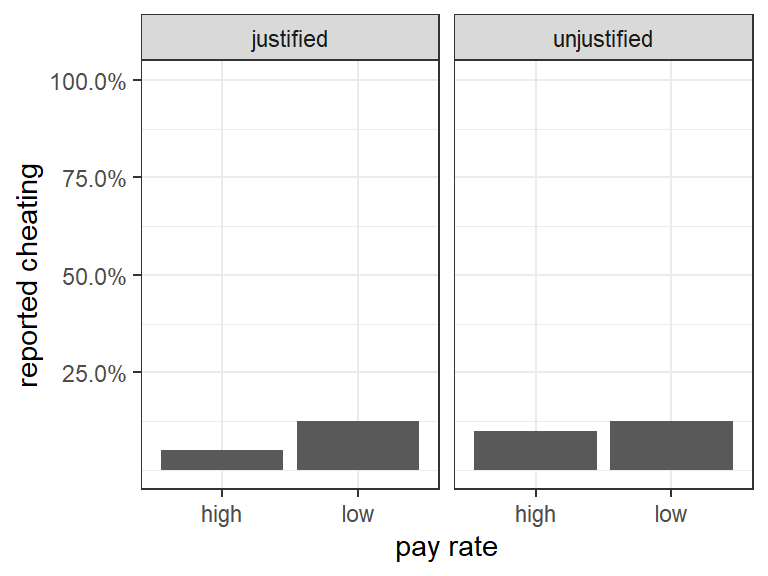

Logistic regression:

```
##
## Call:
## glm(formula = lied_num ~ pay * justification, family = "binomial",
##     data = .)
##
## Deviance Residuals:
##     Min       1Q   Median       3Q      Max
## -0.5168  -0.5168  -0.4590  -0.3203   2.4478
##
## Coefficients:
##                                      Estimate Std. Error z value Pr(>|z|)
## (Intercept)                           -2.2584     0.2808  -8.044  8.7e-16
## payhigh_low                           -0.6249     0.5615  -1.113    0.266
## justificationjust_unjust              -0.3736     0.5615  -0.665    0.506
## payhigh_low:justificationjust_unjust  -0.7472     1.1230  -0.665    0.506
##
## (Intercept)                          ***
## payhigh_low
## justificationjust_unjust
## payhigh_low:justificationjust_unjust
## ---
## Signif. codes:  0 '***' 0.001 '**' 0.01 '*' 0.05 '.' 0.1 ' ' 1
##
## (Dispersion parameter for binomial family taken to be 1)
##
##     Null deviance: 104.03  on 159  degrees of freedom
## Residual deviance: 102.17  on 156  degrees of freedom
## AIC: 110.17
##
## Number of Fisher Scoring iterations: 5
```

|  | lied_num |  |  |  |
| --- | --- | --- | --- | --- |
| Predictors | Odds Ratios | CI | Statistic | p |
| (Intercept) | 0.10 | 0.06 – 0.18 | -8.04 | **<0.001** |
| payhigh_low | 0.54 | 0.18 – 1.61 | -1.11 | 0.266 |
| justificationjust_unjust | 0.69 | 0.23 – 2.07 | -0.67 | 0.506 |
| payhigh_low:justificationjust_unjust | 0.47 | 0.05 – 4.28 | -0.67 | 0.506 |
| Observations | 160 |  |  |  |
| R<sup>2</sup> Tjur | 0.010 |  |  |  |

### 3.5.2 Temptation to cheat

Visually:

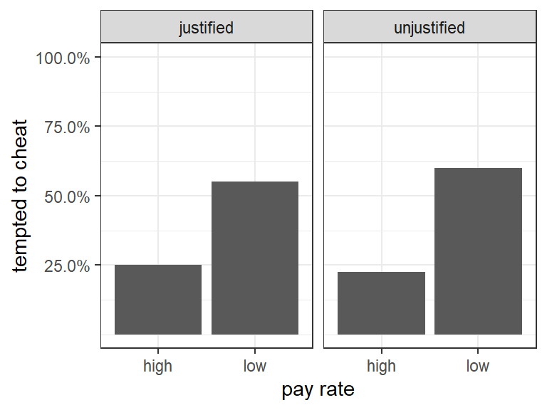

Logistic regression:

```
##
## Call:
## glm(formula = tempted_num ~ pay * justification, family = "binomial",
##     data = .)
##
## Deviance Residuals:
##     Min       1Q   Median       3Q      Max
## -1.3537  -0.7585  -0.7140   1.0935   1.7272
##
## Coefficients:
##                                      Estimate Std. Error z value Pr(>|z|)
## (Intercept)                          -0.43231    0.17354  -2.491   0.0127
## payhigh_low                          -1.47076    0.34709  -4.237 2.26e-05
## justificationjust_unjust             -0.03332    0.34709  -0.096   0.9235
## payhigh_low:justificationjust_unjust  0.34294    0.69417   0.494   0.6213
##
## (Intercept)                          *
## payhigh_low                          ***
## justificationjust_unjust
## payhigh_low:justificationjust_unjust
## ---
## Signif. codes:  0 '***' 0.001 '**' 0.01 '*' 0.05 '.' 0.1 ' ' 1
##
## (Dispersion parameter for binomial family taken to be 1)
##
##     Null deviance: 216.15  on 159  degrees of freedom
## Residual deviance: 196.53  on 156  degrees of freedom
## AIC: 204.53
##
## Number of Fisher Scoring iterations: 4
```

|  | tempted_num |  |  |  |
| --- | --- | --- | --- | --- |
| Predictors | Odds Ratios | CI | Statistic | p |
| (Intercept) | 0.65 | 0.46 – 0.91 | -2.49 | **0.013** |
| payhigh_low | 0.23 | 0.12 – 0.45 | -4.24 | **<0.001** |
| justificationjust_unjust | 0.97 | 0.49 – 1.91 | -0.10 | 0.924 |
| payhigh_low:justificationjust_unjust | 1.41 | 0.36 – 5.49 | 0.49 | 0.621 |
| Observations | 160 |  |  |  |
| R<sup>2</sup> Tjur | 0.120 |  |  |  |

# 4 Experiment 2

Show first rows of the two data sets (see `README` for column key):

| dyad | subject | procedure | outcome | quiz_actual | quiz_official | pay_rate | valence | fair | cheated | tempted_cheat | age | gender |
| --- | --- | --- | --- | --- | --- | --- | --- | --- | --- | --- | --- | --- |
| 2 | 2_a | justified | unequal | winner | winner | 10 | not-disadvant | yes | no | 3 | 20 | male |
| 2 | 2_b | justified | unequal | loser | loser | 5 | disadvant | no | no | 3 | 22 | male |
| 3 | 3_a | justified | equal | winner | equal | 5 | not-disadvant | no | no | 2 | 18 | female |
| 3 | 3_b | justified | equal | loser | equal | 5 | not-disadvant | no | no | 1 | 20 | female |
| 4 | 4_a | unjustified | unequal | loser | loser | 10 | not-disadvant | no | no | 2 | 23 | female |
| 4 | 4_b | unjustified | unequal | winner | winner | 5 | disadvant | no | no | 5 | 21 | female |

| dyad | subject | roll | pips |
| --- | --- | --- | --- |
| 2 | 2_a | 1 | 2 |
| 2 | 2_a | 2 | 2 |
| 2 | 2_a | 3 | 5 |
| 2 | 2_a | 4 | 5 |
| 2 | 2_a | 5 | 3 |
| 2 | 2_a | 6 | 6 |

## 4.1 General descriptives and coding scheme

Total number of participants: 398.

Number of participants per condition:

| outcome | procedure | quiz_official | pay_rate | valence | N |
| --- | --- | --- | --- | --- | --- |
| equal | justified | equal | 5 | not-disadvant | 100 |
| equal | unjustified | loser | 5 | not-disadvant | 49 |
| equal | unjustified | winner | 5 | disadvant | 49 |
| unequal | justified | loser | 5 | disadvant | 49 |
| unequal | justified | winner | 5 | disadvant | 1 |
| unequal | justified | winner | 10 | not-disadvant | 48 |
| unequal | unjustified | loser | 10 | not-disadvant | 51 |
| unequal | unjustified | winner | 5 | disadvant | 51 |

One participant appears to have received the incorrect pay rate; remove them:

| dyad | subject | procedure | outcome | quiz_actual | quiz_official | pay_rate | valence | fair | cheated | tempted_cheat | age | gender |
| --- | --- | --- | --- | --- | --- | --- | --- | --- | --- | --- | --- | --- |
| 77 | 77_a | justified | unequal | winner | winner | 5 | disadvant | no | no | 0 | 25 | female |

Set coding scheme:

```
##         equal_unequal
## equal             0.5
## unequal          -0.5
```

```
##             justif_unjustif
## justified               0.5
## unjustified            -0.5
```

```
##               not-disadv_disadv
## disadvant                  -0.5
## not-disadvant               0.5
```

| dyad | subject | roll | pips | procedure | outcome | quiz_official | pay_rate | valence |
| --- | --- | --- | --- | --- | --- | --- | --- | --- |
| 2 | 2_a | 1 | 2 | justified | unequal | winner | 10 | not-disadvant |
| 2 | 2_a | 2 | 2 | justified | unequal | winner | 10 | not-disadvant |
| 2 | 2_a | 3 | 5 | justified | unequal | winner | 10 | not-disadvant |
| 2 | 2_a | 4 | 5 | justified | unequal | winner | 10 | not-disadvant |

## 4.2 Perception of fairness

Were fairness ratings affected by the manipulated variables?

### 4.2.1 Descriptives

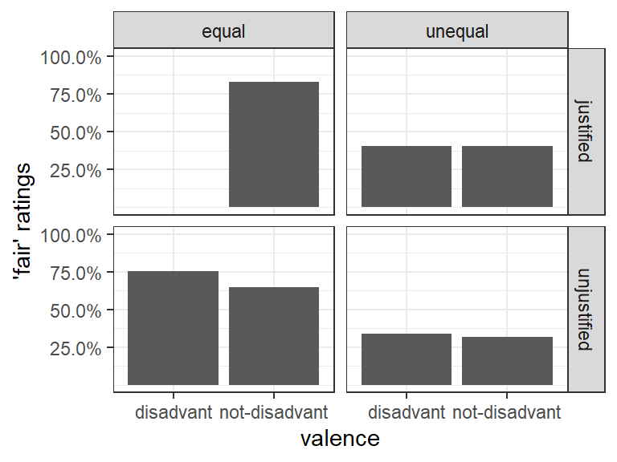

| outcome | prop |
| --- | --- |
| equal | 0.77 |
| unequal | 0.37 |

| procedure | prop |
| --- | --- |
| justified | 0.62 |
| unjustified | 0.51 |

| valence | prop |
| --- | --- |
| disadvant | 0.50 |
| not-disadvant | 0.61 |

### 4.2.2 Main analysis

```
##
## Call:
## glm(formula = make_exp2_formula("fair_num"), family = binomial(link = "logit"),
##     data = e2_ppt)
##
## Deviance Residuals:
##     Min       1Q   Median       3Q      Max
## -1.8772  -1.0178   0.6138   0.9351   1.5096
##
## Coefficients:
##                                                   Estimate Std. Error
## (Intercept)                                        0.38949    0.15034
## outcomeequal_unequal                               1.87529    0.29952
## procedurejustif_unjustif                           0.62413    0.29136
## valencenot-disadv_disadv                          -0.26262    0.30746
## outcomeequal_unequal:procedurejustif_unjustif      0.60673    0.58511
## outcomeequal_unequal:valencenot-disadv_disadv     -0.43476    0.61845
## procedurejustif_unjustif:valencenot-disadv_disadv  0.09048    0.59811
##                                                   z value Pr(>|z|)
## (Intercept)                                         2.591  0.00958 **
## outcomeequal_unequal                                6.261 3.83e-10 ***
## procedurejustif_unjustif                            2.142  0.03219 *
## valencenot-disadv_disadv                           -0.854  0.39302
## outcomeequal_unequal:procedurejustif_unjustif       1.037  0.29977
## outcomeequal_unequal:valencenot-disadv_disadv      -0.703  0.48207
## procedurejustif_unjustif:valencenot-disadv_disadv   0.151  0.87976
## ---
## Signif. codes:  0 '***' 0.001 '**' 0.01 '*' 0.05 '.' 0.1 ' ' 1
##
## (Dispersion parameter for binomial family taken to be 1)
##
##     Null deviance: 533.70  on 389  degrees of freedom
## Residual deviance: 461.39  on 383  degrees of freedom
##   (7 observations deleted due to missingness)
## AIC: 475.39
##
## Number of Fisher Scoring iterations: 4
```

|  | fair_num |  |  |  |
| --- | --- | --- | --- | --- |
| Predictors | Odds Ratios | CI | Statistic | p |
| (Intercept) | 1.48 | 1.10 – 1.98 | 2.59 | **0.010** |
| outcomeequal_unequal | 6.52 | 3.63 – 11.73 | 6.26 | **<0.001** |
| procedurejustif_unjustif | 1.87 | 1.05 – 3.30 | 2.14 | **0.032** |
| valencenot-disadv_disadv | 0.77 | 0.42 – 1.40 | -0.85 | 0.393 |
| outcomeequal_unequal:procedurejustif_unjustif | 1.83 | 0.58 – 5.77 | 1.04 | 0.300 |
| outcomeequal_unequal:valencenot-disadv_disadv | 0.65 | 0.19 – 2.18 | -0.70 | 0.482 |
| procedurejustif_unjustif:valencenot-disadv_disadv | 1.09 | 0.34 – 3.54 | 0.15 | 0.880 |
| Observations | 390 |  |  |  |
| R<sup>2</sup> Tjur | 0.177 |  |  |  |

### 4.2.3 Follow-up analysis using Procedure and Outcome only

A judgement of fairness should not in principle depend on the valence of the outcome. Ethically, fairness is an objective measure, not a matter of how a situation affects *you* in particular. So first, we re-run the analysis without valence as a predictor.

Visually:

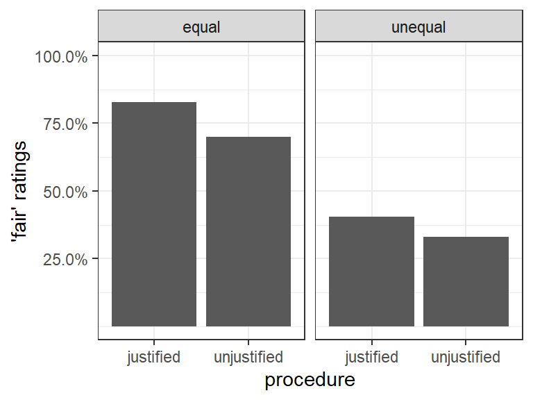

Analysis:

|  | fair_num |  |  |  |
| --- | --- | --- | --- | --- |
| Predictors | Odds Ratios | CI | Statistic | p |
| (Intercept) | 1.39 | 1.11 – 1.75 | 2.90 | **0.004** |
| procedurejustif_unjustif | 1.68 | 1.07 – 2.64 | 2.28 | **0.023** |
| outcomeequal_unequal | 5.82 | 3.71 – 9.11 | 7.69 | **<0.001** |
| procedurejustif_unjustif:outcomeequal_unequal | 1.49 | 0.61 – 3.66 | 0.88 | 0.381 |
| Observations | 390 |  |  |  |
| R<sup>2</sup> Tjur | 0.173 |  |  |  |

## 4.3 Dishonesty measure: Average Reported Score (ARS)

### 4.3.1 Descriptives

| dyad | subject | outcome | procedure | valence | ARS | ARS_bias |
| --- | --- | --- | --- | --- | --- | --- |
| 2 | 2_a | unequal | justified | not-disadvant | 4.17 | 0.67 |
| 2 | 2_b | unequal | justified | disadvant | 3.75 | 0.25 |
| 3 | 3_a | equal | justified | not-disadvant | 3.58 | 0.08 |

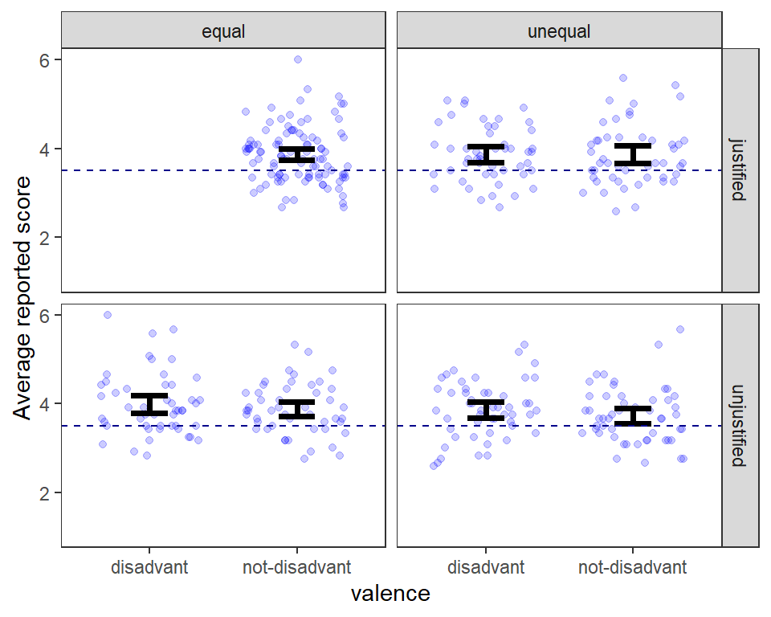

| outcome | procedure | valence | mean | SD |
| --- | --- | --- | --- | --- |
| equal | justified | not-disadvant | 3.86 | 0.64 |
| equal | unjustified | disadvant | 3.98 | 0.70 |
| equal | unjustified | not-disadvant | 3.88 | 0.58 |
| unequal | justified | disadvant | 3.87 | 0.62 |
| unequal | justified | not-disadvant | 3.86 | 0.70 |
| unequal | unjustified | disadvant | 3.86 | 0.64 |
| unequal | unjustified | not-disadvant | 3.73 | 0.63 |

### 4.3.2 Analysis

For the analysis we use *ARS_bias* ($ARS - 3.5$) instead of ARS:

```
##
## Call:
## lm(formula = ARS_bias ~ procedure * outcome + procedure * valence +
##     outcome * valence, data = e2_ars)
##
## Residuals:
##      Min       1Q   Median       3Q      Max
## -1.27941 -0.46088 -0.06209  0.39063  2.14250
##
## Coefficients:
##                                                    Estimate Std. Error
## (Intercept)                                        0.359150   0.042711
## procedurejustif_unjustif                          -0.008575   0.085421
## outcomeequal_unequal                               0.060037   0.085679
## valencenot-disadv_disadv                          -0.056707   0.092207
## procedurejustif_unjustif:outcomeequal_unequal     -0.150668   0.171357
## procedurejustif_unjustif:valencenot-disadv_disadv  0.127716   0.182607
## outcomeequal_unequal:valencenot-disadv_disadv      0.026844   0.182124
##                                                   t value Pr(>|t|)
## (Intercept)                                         8.409 7.88e-16 ***
## procedurejustif_unjustif                           -0.100    0.920
## outcomeequal_unequal                                0.701    0.484
## valencenot-disadv_disadv                           -0.615    0.539
## procedurejustif_unjustif:outcomeequal_unequal      -0.879    0.380
## procedurejustif_unjustif:valencenot-disadv_disadv   0.699    0.485
## outcomeequal_unequal:valencenot-disadv_disadv       0.147    0.883
## ---
## Signif. codes:  0 '***' 0.001 '**' 0.01 '*' 0.05 '.' 0.1 ' ' 1
##
## Residual standard error: 0.6438 on 390 degrees of freedom
## Multiple R-squared:  0.01015,    Adjusted R-squared:  -0.005077
## F-statistic: 0.6666 on 6 and 390 DF,  p-value: 0.6767
```

|  | ARS_bias |  |  |  |
| --- | --- | --- | --- | --- |
| Predictors | Estimates | CI | Statistic | p |
| (Intercept) | 0.36 | 0.28 – 0.44 | 8.41 | **<0.001** |
| procedurejustif_unjustif | -0.01 | -0.18 – 0.16 | -0.10 | 0.920 |
| outcomeequal_unequal | 0.06 | -0.11 – 0.23 | 0.70 | 0.484 |
| valencenot-disadv_disadv | -0.06 | -0.24 – 0.12 | -0.61 | 0.539 |
| procedurejustif_unjustif:outcomeequal_unequal | -0.15 | -0.49 – 0.19 | -0.88 | 0.380 |
| procedurejustif_unjustif:valencenot-disadv_disadv | 0.13 | -0.23 – 0.49 | 0.70 | 0.485 |
| outcomeequal_unequal:valencenot-disadv_disadv | 0.03 | -0.33 – 0.38 | 0.15 | 0.883 |
| Observations | 397 |  |  |  |
| R<sup>2</sup> / R<sup>2</sup> adjusted | 0.010 / -0.005 |  |  |  |

### 4.3.3 Each condition against chance (t-tests)

| outcome | procedure | valence | M | SD | df | t | p_unadj | p_adjusted |
| --- | --- | --- | --- | --- | --- | --- | --- | --- |
| equal | justified | not-disadvant | 0.36 | 0.64 | 99 | 5.61 | 0.0000 | 0.0000 |
| equal | unjustified | disadvant | 0.48 | 0.70 | 48 | 4.82 | 0.0000 | 0.0001 |
| equal | unjustified | not-disadvant | 0.38 | 0.58 | 48 | 4.58 | 0.0000 | 0.0002 |
| unequal | justified | disadvant | 0.37 | 0.62 | 48 | 4.12 | 0.0001 | 0.0006 |
| unequal | justified | not-disadvant | 0.36 | 0.70 | 47 | 3.56 | 0.0009 | 0.0017 |
| unequal | unjustified | disadvant | 0.36 | 0.64 | 50 | 4.06 | 0.0002 | 0.0006 |
| unequal | unjustified | not-disadvant | 0.23 | 0.63 | 50 | 2.60 | 0.0122 | 0.0122 |

## 4.4 Reported cheating and temptation to cheat

Of all participants, 24% reported having cheated.

**Descriptive table**

[output not shown]

### 4.4.1 Reported cheating

#### 4.4.1.1 Default coding for valence

Visually:

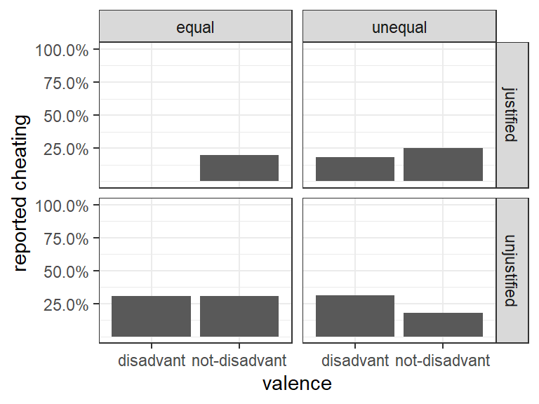

| procedure | prop |
| --- | --- |
| justified | 0.21 |
| unjustified | 0.28 |

Logistic regression:

```
##
## Call:
## glm(formula = make_exp2_formula("cheated_num"), family = "binomial",
##     data = e2_ppt)
##
## Deviance Residuals:
##     Min       1Q   Median       3Q      Max
## -0.8677  -0.8549  -0.6681  -0.6300   1.8519
##
## Coefficients:
##                                                   Estimate Std. Error
## (Intercept)                                        -1.3032     0.1640
## outcomeequal_unequal                               -0.1616     0.3003
## procedurejustif_unjustif                           -0.6384     0.3105
## valencenot-disadv_disadv                            0.1965     0.3314
## outcomeequal_unequal:procedurejustif_unjustif      -0.9857     0.6365
## outcomeequal_unequal:valencenot-disadv_disadv       0.7336     0.6471
## procedurejustif_unjustif:valencenot-disadv_disadv   1.1266     0.6883
##                                                   z value Pr(>|z|)
## (Intercept)                                        -7.947  1.9e-15 ***
## outcomeequal_unequal                               -0.538   0.5905
## procedurejustif_unjustif                           -2.056   0.0398 *
## valencenot-disadv_disadv                            0.593   0.5532
## outcomeequal_unequal:procedurejustif_unjustif      -1.549   0.1215
## outcomeequal_unequal:valencenot-disadv_disadv       1.134   0.2569
## procedurejustif_unjustif:valencenot-disadv_disadv   1.637   0.1017
## ---
## Signif. codes:  0 '***' 0.001 '**' 0.01 '*' 0.05 '.' 0.1 ' ' 1
##
## (Dispersion parameter for binomial family taken to be 1)
##
##     Null deviance: 438.66  on 395  degrees of freedom
## Residual deviance: 432.12  on 389  degrees of freedom
##   (1 observation deleted due to missingness)
## AIC: 446.12
##
## Number of Fisher Scoring iterations: 4
```

|  | cheated_num |  |  |  |
| --- | --- | --- | --- | --- |
| Predictors | Odds Ratios | CI | Statistic | p |
| (Intercept) | 0.27 | 0.20 – 0.37 | -7.95 | **<0.001** |
| outcomeequal_unequal | 0.85 | 0.47 – 1.53 | -0.54 | 0.590 |
| procedurejustif_unjustif | 0.53 | 0.29 – 0.97 | -2.06 | **0.040** |
| valencenot-disadv_disadv | 1.22 | 0.64 – 2.33 | 0.59 | 0.553 |
| outcomeequal_unequal:procedurejustif_unjustif | 0.37 | 0.11 – 1.30 | -1.55 | 0.121 |
| outcomeequal_unequal:valencenot-disadv_disadv | 2.08 | 0.59 – 7.40 | 1.13 | 0.257 |
| procedurejustif_unjustif:valencenot-disadv_disadv | 3.09 | 0.80 – 11.89 | 1.64 | 0.102 |
| Observations | 396 |  |  |  |
| R<sup>2</sup> Tjur | 0.017 |  |  |  |

### 4.4.2 Temptation to cheat

Temptation to cheat was indicated as a rating on a scale from 0 (not at all) to 5 (very much). The mean rating was 2.6.

Visually:

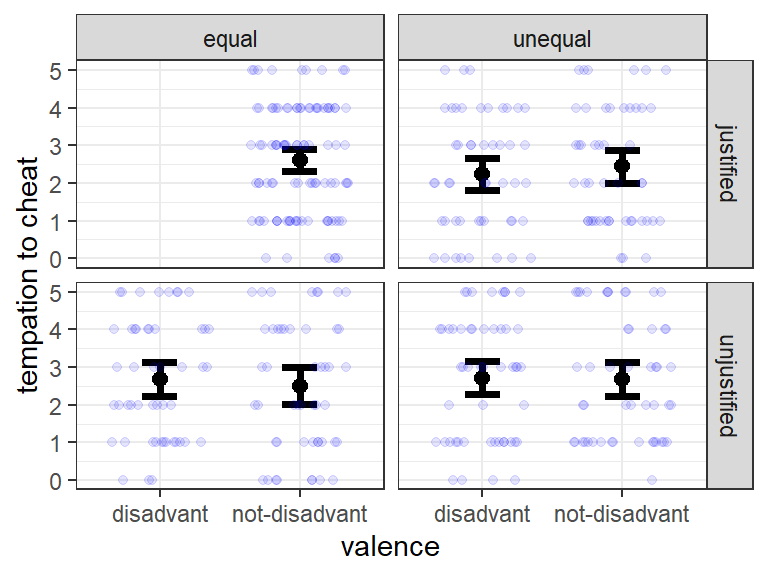

Linear regression:

```
##
## Call:
## lm(formula = tempted_cheat ~ procedure * outcome + procedure *
##     valence + outcome * valence, data = e2_ppt)
##
## Residuals:
##     Min      1Q  Median      3Q     Max
## -2.7059 -1.4898  0.2941  1.4040  2.7551
##
## Coefficients:
##                                                    Estimate Std. Error
## (Intercept)                                        2.546949   0.105328
## procedurejustif_unjustif                          -0.177410   0.209470
## outcomeequal_unequal                               0.063023   0.210100
## valencenot-disadv_disadv                           0.004464   0.225948
## procedurejustif_unjustif:outcomeequal_unequal      0.342133   0.422564
## procedurejustif_unjustif:valencenot-disadv_disadv  0.225015   0.449688
## outcomeequal_unequal:valencenot-disadv_disadv     -0.151261   0.448510
##                                                   t value Pr(>|t|)
## (Intercept)                                        24.181   <2e-16 ***
## procedurejustif_unjustif                           -0.847    0.398
## outcomeequal_unequal                                0.300    0.764
## valencenot-disadv_disadv                            0.020    0.984
## procedurejustif_unjustif:outcomeequal_unequal       0.810    0.419
## procedurejustif_unjustif:valencenot-disadv_disadv   0.500    0.617
## outcomeequal_unequal:valencenot-disadv_disadv      -0.337    0.736
## ---
## Signif. codes:  0 '***' 0.001 '**' 0.01 '*' 0.05 '.' 0.1 ' ' 1
##
## Residual standard error: 1.578 on 387 degrees of freedom
##   (3 observations deleted due to missingness)
## Multiple R-squared:  0.008529,   Adjusted R-squared:  -0.006843
## F-statistic: 0.5548 on 6 and 387 DF,  p-value: 0.7662
```

|  | tempted_cheat |  |  |  |
| --- | --- | --- | --- | --- |
| Predictors | Estimates | CI | Statistic | p |
| (Intercept) | 2.55 | 2.34 – 2.75 | 24.18 | **<0.001** |
| procedurejustif_unjustif | -0.18 | -0.59 – 0.23 | -0.85 | 0.398 |
| outcomeequal_unequal | 0.06 | -0.35 – 0.47 | 0.30 | 0.764 |
| valencenot-disadv_disadv | 0.00 | -0.44 – 0.45 | 0.02 | 0.984 |
| procedurejustif_unjustif:outcomeequal_unequal | 0.34 | -0.49 – 1.17 | 0.81 | 0.419 |
| procedurejustif_unjustif:valencenot-disadv_disadv | 0.23 | -0.66 – 1.11 | 0.50 | 0.617 |
| outcomeequal_unequal:valencenot-disadv_disadv | -0.15 | -1.03 – 0.73 | -0.34 | 0.736 |
| Observations | 394 |  |  |  |
| R<sup>2</sup> / R<sup>2</sup> adjusted | 0.009 / -0.007 |  |  |  |